# Practical Machine Learning - Prediction Assignment Writeup

Thiago Veras

September 23, 2015

### Synopsis

Using devices such as Jawbone Up, Nike FuelBand, and Fitbit it is now possible to collect a large amount of data about personal activity relatively inexpensively. These type of devices are part of the quantified self movement – a group of enthusiasts who take measurements about themselves regularly to improve their health, to find patterns in their behavior, or because they are tech geeks. One thing that people regularly do is quantify how much of a particular activity they do, but they rarely quantify how well they do it. In this project, your goal will be to use data from accelerometers on the belt, forearm, arm, and dumbell of 6 participants. They were asked to perform barbell lifts correctly and incorrectly in 5 different ways. More information is available from the website here: http://groupware.les.inf.puc-rio.br/har (see the section on the Weight Lifting Exercise Dataset).

### Data Processing

#### 1. Configuring Workspace

```r
# Setting Working Directory
setwd("~/Desktop/practical-machine-learning")

# Installing required libraries
require(knitr)
require(caret)
require(randomForest)
```

```r
require(rpart.plot)
require(e1071)
# Configuring some options
options(width = 100)
opts_chunk$set(message = F, error = F, warning = F, comment = NA, fig.align = 'center', dpi = 100, tidy = F, cache.path = '.cache/', fig.path = 'fig/')

options(xtable.type = 'html')
knit_hooks$set(inline = function(x) {
  if(is.numeric(x)) {
    round(x, getOption('digits'))
  } else {
    paste(as.character(x), collapse = ', ')
  }
})
knit_hooks$set(plot = knitr:::hook_plot_html)
```

#### 2. Data Loading

```r
# Loading the Training Data
training_data <- read.csv("data/pml-training.csv",na.strings=c("NA","#DIV/0!", ""))
# Loading the Testing Data
testing_data <- read.csv("data/pml-testing.csv",na.strings=c("NA","#DIV/0!", ""))

# Taking a look in one line of each data, just to verify
# head(training_data, n = 1)
# head(testing_data, n = 1)
```

#### 3. Data Exploring

```r
# Verifiying the dimension of the training data
dim(training_data)
```

```
[1] 19622   160
```

```r
# Verifiying the dimension of the testing data
dim(testing_data)
```

```
[1]  20 160
```

```r
# Tabulating the classes of the training data
table(training_data$classe)
```

```
   A    B    C    D    E
5580 3797 3422 3216 3607
```

#### 4. Data Cleaning

```r
# Removing the NA data from training data
training_data_no_na = training_data[,!apply(training_data,2,function(x) any(is.na(x)) )]
# Removing the Information data (columns from 1 to 6)
cleaned_training_data = training_data_no_na[,-c(1:6)]
# Verify one line of the cleaned training data
head(cleaned_training_data, n=1)
```

```
  num_window roll_belt pitch_belt yaw_belt total_accel_belt gyros_belt_x gyros_belt_y gyros_belt_z
1         11      1.41       8.07    -94.4                3            0            0        -0.02
  accel_belt_x accel_belt_y accel_belt_z magnet_belt_x magnet_belt_y magnet_belt_z roll_arm
1          -21            4           22            -3           599          -313     -128
  pitch_arm yaw_arm total_accel_arm gyros_arm_x gyros_arm_y gyros_arm_z accel_arm_x accel_arm_y
1      22.5    -161              34           0           0       -0.02        -288         109
  accel_arm_z magnet_arm_x magnet_arm_y magnet_arm_z roll_dumbbell pitch_dumbbell yaw_dumbbell
1        -123         -368          337          516      13.05217        -70.494    -84.87394
  total_accel_dumbbell gyros_dumbbell_x gyros_dumbbell_y gyros_dumbbell_z accel_dumbbell_x
1                   37                0            -0.02                0             -234
  accel_dumbbell_y accel_dumbbell_z magnet_dumbbell_x magnet_dumbbell_y magnet_dumbbell_z
1               47             -271              -559               293               -65
  roll_forearm pitch_forearm yaw_forearm total_accel_forearm gyros_forearm_x gyros_forearm_y
1         28.4         -63.9        -153                  36            0.03               0
  gyros_forearm_z accel_forearm_x accel_forearm_y accel_forearm_z magnet_forearm_x magnet_forearm_y
1           -0.02             192             203            -215              -17              654
  magnet_forearm_z classe
1              476      A
```

```r
# Verifying the dimension of the training data after the clean process
dim(cleaned_training_data)
```

```
[1] 19622    54
```

```r
# Verifying if the classe distribution continues the same
table(cleaned_training_data$classe)
```

```
   A    B    C    D    E
5580 3797 3422 3216 3607
```

```r
# Removing the NA data from testing data too
testing_data_no_na = testing_data[,!apply(testing_data,2,function(x) any(is.na(x)) )]
# Removing the Information data (columns from 1 to 6)
cleaned_testing_data = testing_data_no_na[,-c(1:6)]

# Verifying the dimension of testing data after the clean process
dim(cleaned_testing_data)
```

```
[1] 20 54
```

#### 5. Data Spliting

```r
#Spliting the training data for cross validation in two groups [60% and 40%]
sub_groups = createDataPartition(y=cleaned_training_data$classe, p=0.6, list=FALSE)
sub_group_for_training = cleaned_training_data[sub_groups, ]
sub_group_for_testing = cleaned_training_data[-sub_groups, ]

# Verifying the dimension of sup group #1 (60% for training)
dim(sub_group_for_training)
```

```
[1] 11776    54
```

```r
# Verifying the dimension of sup group #2 (40% for testing)
dim(sub_group_for_testing)
```

```
[1] 7846   54
```

#### 6. Data Manipulation

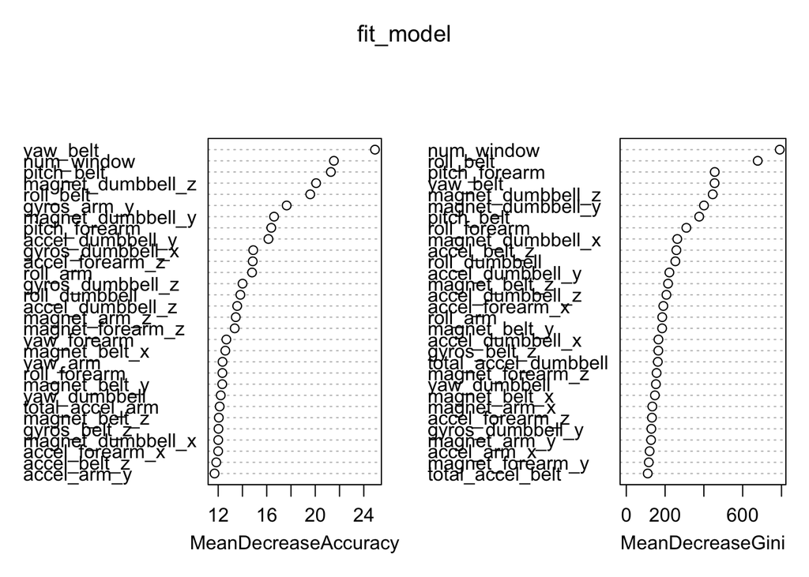

```r
set.seed(3141592)
fit_model <- randomForest(classe~., data=sub_group_for_training, importance=TRUE, ntree=100)
varImpPlot(fit_model)
```

Using the graphs above, we select the top 10 variables

```r
# Defining the top 10 variables based on the graphs
top10variables <- c("yaw_belt","roll_belt","num_window","pitch_belt","magnet_dumbbell_z","magnet_dumbbell_y","pitch_forearm","accel_dumbbell_y","roll_arm","roll_forearm")

# Analyzing the correlations between these 10 variables
correlations = cor(sub_group_for_training[,top10variables])
# Diagnonal with 0
diag(correlations) <- 0
# Absolute value correlation above 75%
which(abs(correlations)>0.75, arr.ind=TRUE)
```

```
          row col
roll_belt   2   1
yaw_belt    1   2
```

We have a problem between yaw_belt and roll_belt with a high correlation.

```r
# Analyzing the correlations between yaw_belt and roll_belt
cor(sub_group_for_training$yaw_belt, sub_group_for_training$roll_belt)
```

```
[1] 0.8148978
```

We eliminate the yaw_belt and run again the correlations

```r
# Defining the top 9 variables based on the previous results
top9variables <- c("roll_belt","num_window","pitch_belt","magnet_dumbbell_z","magnet_dumbbell_y","pitch_forearm","accel_dumbbell_y","roll_arm","roll_forearm")

# Analyzing the correlations between these 9 variables
correlations = cor(sub_group_for_training[,top9variables])
# Diagnonal with 0
diag(correlations) <- 0
# Absolute value correlation above 75%
which(abs(correlations)>0.75, arr.ind=TRUE)
```

```
     row col
```

With these top 9 variables no correlations above 75%. Let’s validate the decision.

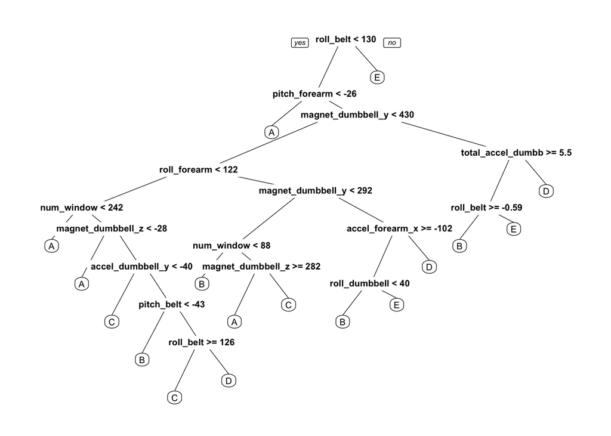

```r
# Tree classifier to identify if is better to remove yaw_belt or roll_belt
fit_model <- rpart(classe~., data=sub_group_for_training, method="class")
prp(fit_model)
```

A quick tree classifier selects roll_belt as the first discriminant among all variables. This tree can prove that was a good choice eliminate the yaw_belt instead of roll_belt.

#### 7. Data Modeling

```r
set.seed(3141592)
#Training the machine
fit_model <- train(classe~roll_belt +
                          num_window +
                          pitch_belt +
                          magnet_dumbbell_y +
                          magnet_dumbbell_z +
                          pitch_forearm +
                          accel_dumbbell_y +
                          roll_arm +
                          roll_forearm,
                  data=sub_group_for_training,
                  method="rf",
                  trControl=trainControl(method="cv",number=2),
                  prox=TRUE,
                  verbose=TRUE,
                  allowParallel=TRUE)

# Saving the model
saveRDS(fit_model, "model_random_forest.Rds")
# Reading the model
fit_model <- readRDS("model_random_forest.Rds")
```

### Results

#### 1. Accuracy

```r
# Predicting with the fit model and sub group for testing (40% of original training data)
predictions <- predict(fit_model, newdata=sub_group_for_testing)
confusion_matrix <- confusionMatrix(predictions, sub_group_for_testing$classe)
confusion_matrix
```

```
Confusion Matrix and Statistics

          Reference
Prediction    A    B    C    D    E
         A 2231    3    0    0    0
         B    1 1513    4    0    2
         C    0    0 1364    7    0
         D    0    2    0 1279    0
         E    0    0    0    0 1440

Overall Statistics

               Accuracy : 0.9976
                 95% CI : (0.9962, 0.9985)
    No Information Rate : 0.2845
    P-Value [Acc > NIR] : < 2.2e-16

                  Kappa : 0.9969
 Mcnemar's Test P-Value : NA

Statistics by Class:

                     Class: A Class: B Class: C Class: D Class: E
Sensitivity            0.9996   0.9967   0.9971   0.9946   0.9986
Specificity            0.9995   0.9989   0.9989   0.9997   1.0000
Pos Pred Value         0.9987   0.9954   0.9949   0.9984   1.0000
Neg Pred Value         0.9998   0.9992   0.9994   0.9989   0.9997
Prevalence             0.2845   0.1935   0.1744   0.1639   0.1838
Detection Rate         0.2843   0.1928   0.1738   0.1630   0.1835
Detection Prevalence   0.2847   0.1937   0.1747   0.1633   0.1835
Balanced Accuracy      0.9995   0.9978   0.9980   0.9971   0.9993
```

#### 2. Out of sample error rate

```r
# Defining the Out of sample error rate
out_of_sample_error_rate = sum(predictions != sub_group_for_testing$classe) / length(sub_group_for_testing$classe)
out_of_sample_error_rate
```

```
[1] 0.002421616
```

### Prediction Assignment Submission

#### Executing the classification of 20 observations using a Random Forest algorithm

```r
# Predicting with the fit model and the cleaned testing data (from pml-testing.csv)
predictions <- predict(fit_model, newdata=cleaned_testing_data)
cleaned_testing_data$classe <- predictions

# Submiting a csv file with problem id and predicted "classe"
submit <- data.frame(problem_id = cleaned_testing_data$problem_id, classe = predictions)
write.csv(submit, file = "coursera-submission.csv", row.names = FALSE)

# Creating the answers files for each problem with the predicted "classe" inside of the file
answers = cleaned_testing_data$classe
write_files = function(x){
  n = length(x)
  for(i in 1:n){
    filename = paste0("problem_",i,".txt")
    write.table(x[i], file=filename, quote=FALSE, row.names=FALSE, col.names=FALSE)
  }
}
write_files(answers)

# OBS: The submition for Coursera is via upload in the web app.
```

### Conclusion

In this assignment, we analyzed and worked with an interesting database.

We did some cleaning in the data and then submit it for some tests. Finally, we trained the machine learning using random forest algorithm and obtained success in 20 observations/tests suggested by Coursera.

Our accuracy reached 99.76% and the out of sample error rate was 0.24%.